# Stationarity & introductory functions

3 April 2025

## Topics for today

Characteristics of time series

- Expectation, mean & variance
- Covariance & correlation
- Stationarity
- Autocovariance & autocorrelation
- Correlograms

White noise

Random walks

Backshift & difference operators

## Code for today

You can find the R code for these lecture notes and other related exercises here.

## Expectation & the mean

The expectation (\(E\)) of a variable is its mean value in the population

\(\text{E}(x) \equiv\) mean of \(x = \mu\)

We can estimate \(\mu\) from a sample as

\[ m = \frac{1}{N} \sum_{i=1}^N{x_i} \]

## Variance

\(\text{E}([x - \mu]^2) \equiv\) expected deviations of \(x\) about \(\mu\)

\(\text{E}([x - \mu]^2) \equiv\) variance of \(x = \sigma^2\)

We can estimate \(\sigma^2\) from a sample as

\[ s^2 = \frac{1}{N-1}\sum_{i=1}^N{(x_i - m)^2} \]

## Covariance

If we have two variables, \(x\) and \(y\), we can generalize variance

\[ \sigma^2 = \text{E}([x_i - \mu][x_i - \mu]) \]

into *covariance*

\[ \gamma_{x,y} = \text{E}([x_i - \mu_x][y_i - \mu_y]) \]

## Covariance

If we have two variables, \(x\) and \(y\), we can generalize variance

\[ \sigma^2 = \text{E}([x_i - \mu][x_i - \mu]) \]

into *covariance*

\[ \gamma_{x,y} = \text{E}([x_i - \mu_x][y_i - \mu_y]) \]

We can estimate \(\gamma_{x,y}\) from a sample as

\[ \text{Cov}(x,y) = \frac{1}{N-1}\sum_{i=1}^N{(x_i - m_x)(y_i - m_y)} \]

## Graphical example of covariance

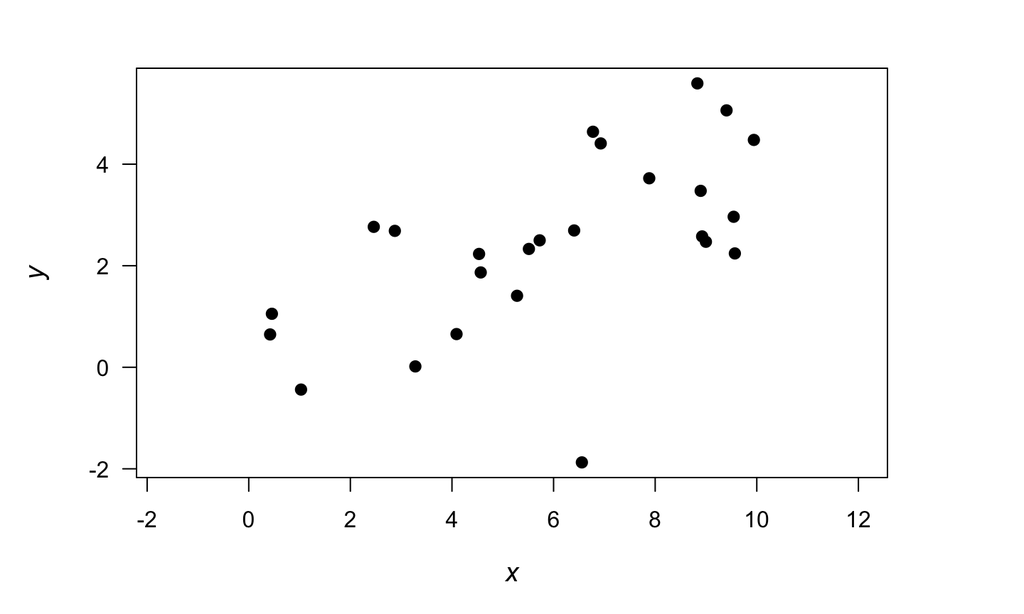

## Graphical example of covariance

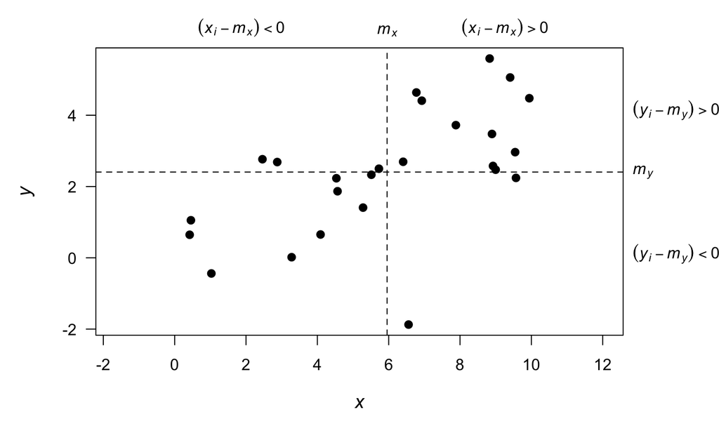

## Graphical example of covariance

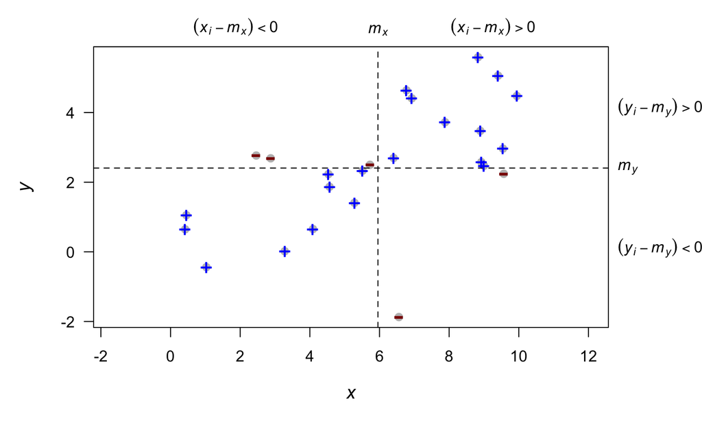

## Correlation

*Correlation* is a dimensionless measure of the linear association between 2 variables, \(x\) & \(y\)

It is simply the covariance standardized by the standard deviations

\[ \rho_{x,y} = \frac{\gamma_{x,y}}{\sigma_x \sigma_y} \]

\[ -1 \leq \rho_{x,y} \leq 1 \]

## Correlation

*Correlation* is a dimensionless measure of the linear association between 2 variables \(x\) & \(y\)

It is simply the covariance standardized by the standard deviations

\[ \rho_{x,y} = \frac{\gamma_{x,y}}{\sigma_x \sigma_y} \]

We can estimate \(\rho_{x,y}\) from a sample as

\[ \text{Cor}(x,y) = \frac{\text{Cov}(x,y)}{s_x s_y} \]

## Stationarity & the mean

Consider a single value, \(x_t\)

## Stationarity & the mean

Consider a single value, \(x_t\)

\(\text{E}(x_t)\) is taken across an ensemble of *all* possible time series

## Stationarity & the mean

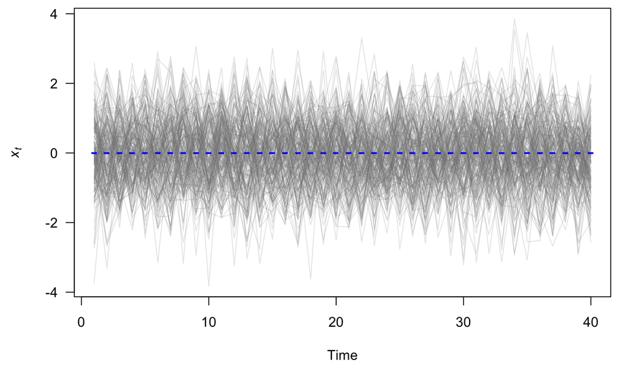

## Stationarity & the mean

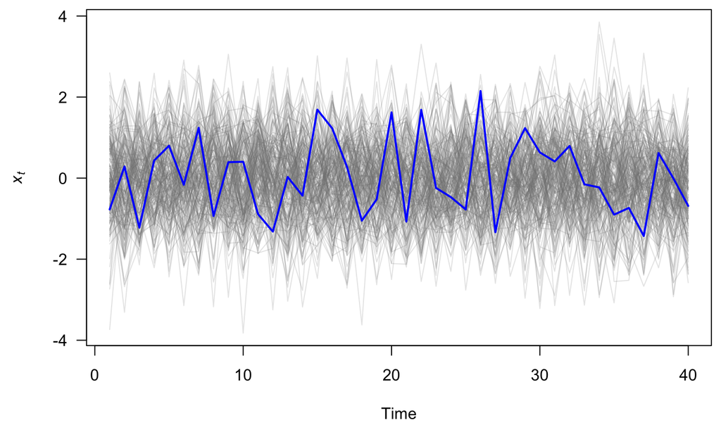

Our single realization is our estimate!

## Stationarity & the mean

If \(\text{E}(x_t)\) is constant across time, we say the time series is *stationary* in the mean

## Stationarity of time series

*Stationarity* is a convenient assumption that allows us to describe the statistical properties of a time series.

In general, a time series is said to be stationary if there is

1. no systematic change in the mean or variance
2. no systematic trend
3. no periodic variations or seasonality

## Identifying stationarity

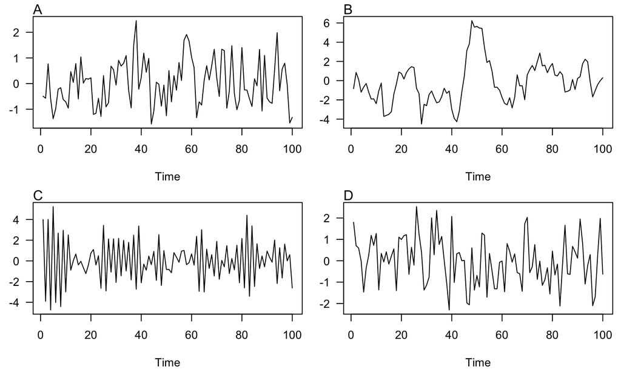

## Identifying stationarity

Our eyes are really bad at identifying stationarity, so we will learn some tools to help us

## Autocovariance function (ACVF)

For stationary ts, we define the *autocovariance function* (\(\gamma_k\)) as

\[ \gamma_k = \text{E}([x_t - \mu][x_{t+k} - \mu]) \]

which means that

\[ \gamma_0 = \text{E}([x_t - \mu][x_{t} - \mu]) = \sigma^2 \]

## Autocovariance function (ACVF)

For stationary ts, we define the *autocovariance function* (\(\gamma_k\)) as

\[ \gamma_k = \text{E}([x_t - \mu][x_{t+k} - \mu]) \]

“Smooth” time series have large ACVF for large \(k\)

“Choppy” time series have ACVF near 0 for small \(k\)

## Autocovariance function (ACVF)

For stationary ts, we define the *autocovariance function* (\(\gamma_k\)) as

\[ \gamma_k = \text{E}([x_t - \mu][x_{t+k} - \mu]) \]

We can estimate \(\gamma_k\) from a sample as

\[ c_k = \frac{1}{N}\sum_{t=1}^{N-k}{(x_t - m)(x_{t+k} - m)} \]

## Autocorrelation function (ACF)

The *autocorrelation function* (ACF) is simply the ACVF normalized by the variance

\[ \rho_k = \frac{\gamma_k}{\sigma^2} = \frac{\gamma_k}{\gamma_0} \]

The ACF measures the correlation of a time series against a time-shifted version of itself

## Autocorrelation function (ACF)

The *autocorrelation function* (ACF) is simply the ACVF normalized by the variance

\[ \rho_k = \frac{\gamma_k}{\sigma^2} = \frac{\gamma_k}{\gamma_0} \]

The ACF measures the correlation of a time series against a time-shifted version of itself

We can estimate ACF from a sample as

\[ r_k = \frac{c_k}{c_0} \]

## Properties of the ACF

The ACF has several important properties:

- \(-1 \leq r_k \leq 1\)
- \(r_k = r_{-k}\)
- \(r_k\) of a periodic function is itself periodic
- \(r_k\) for the sum of 2 independent variables is the sum of \(r_k\) for each of them

## The correlogram

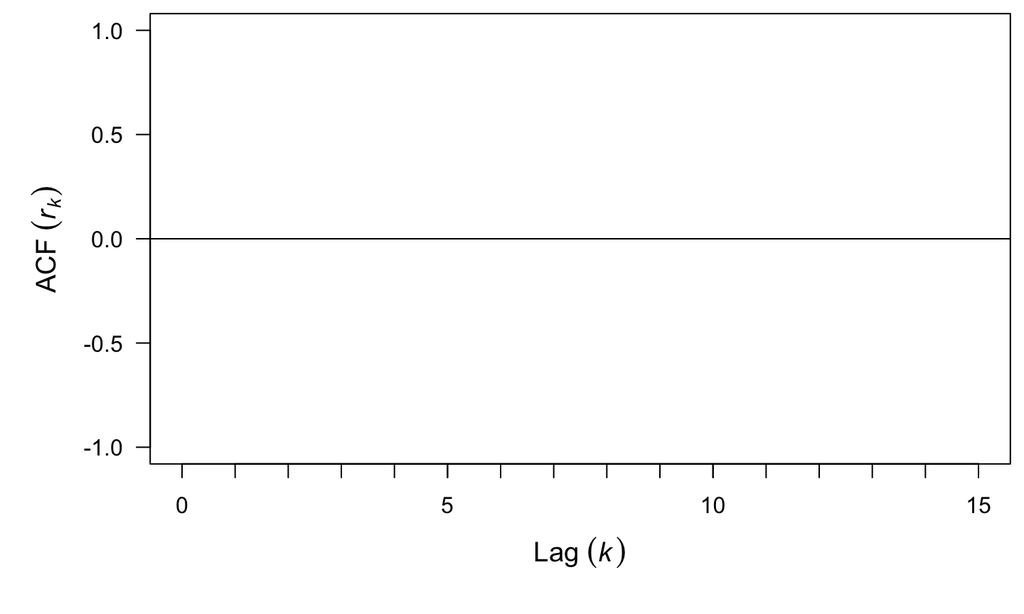

Graphical output for the ACF

## The correlogram

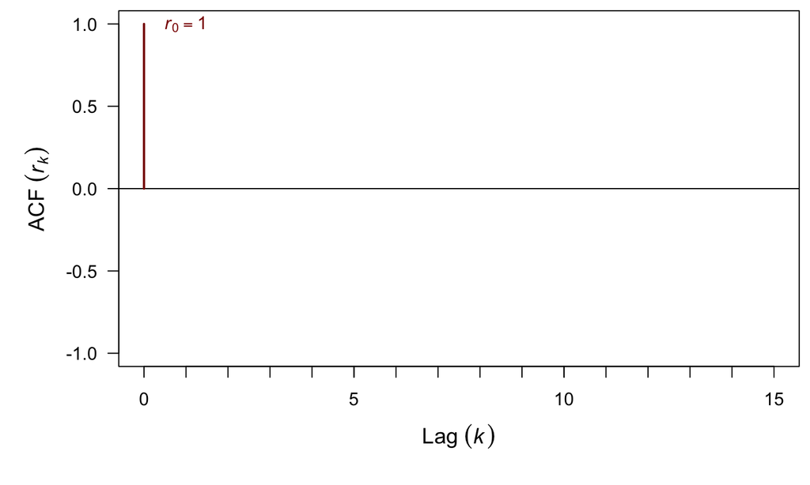

The ACF at lag = 0 is always 1

## The correlogram

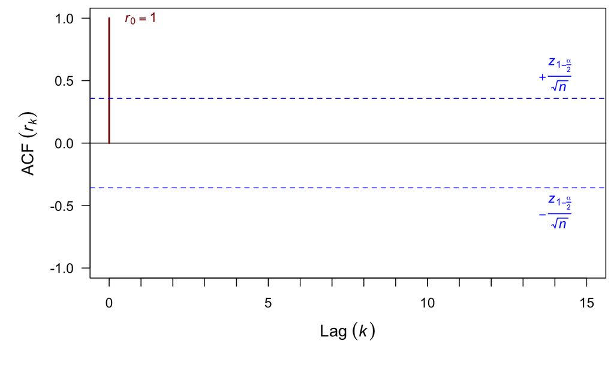

Approximate confidence intervals

## Estimating the ACF in R

```r
acf(ts_object)
```

## ACF for deterministic forms

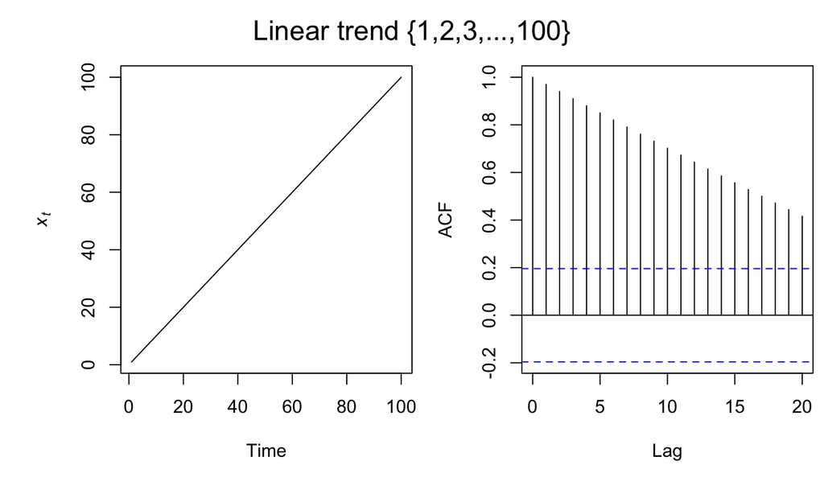

## ACF for deterministic forms

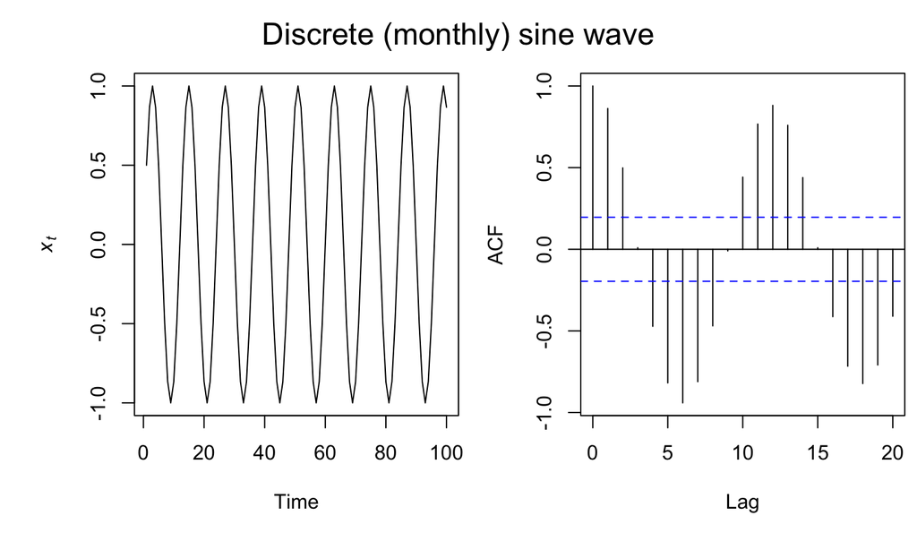

## ACF for deterministic forms

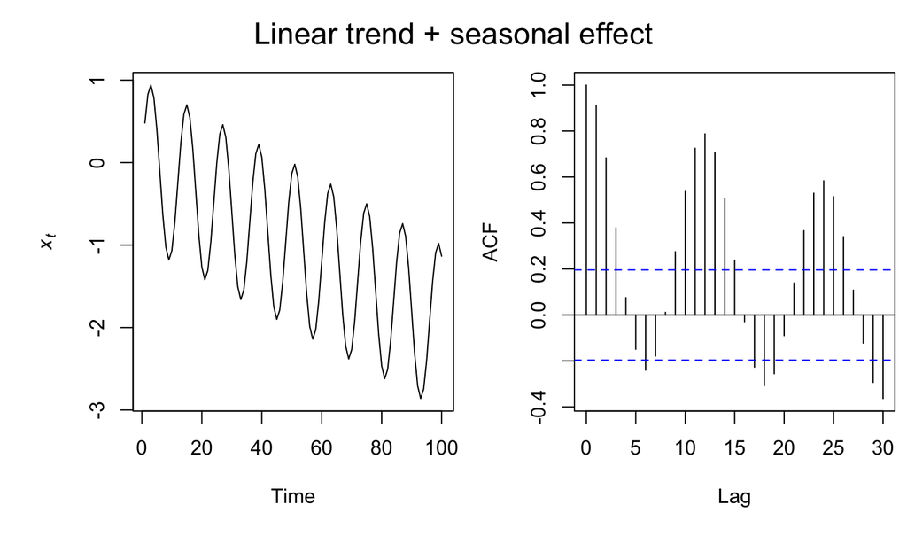

## ACF for deterministic forms

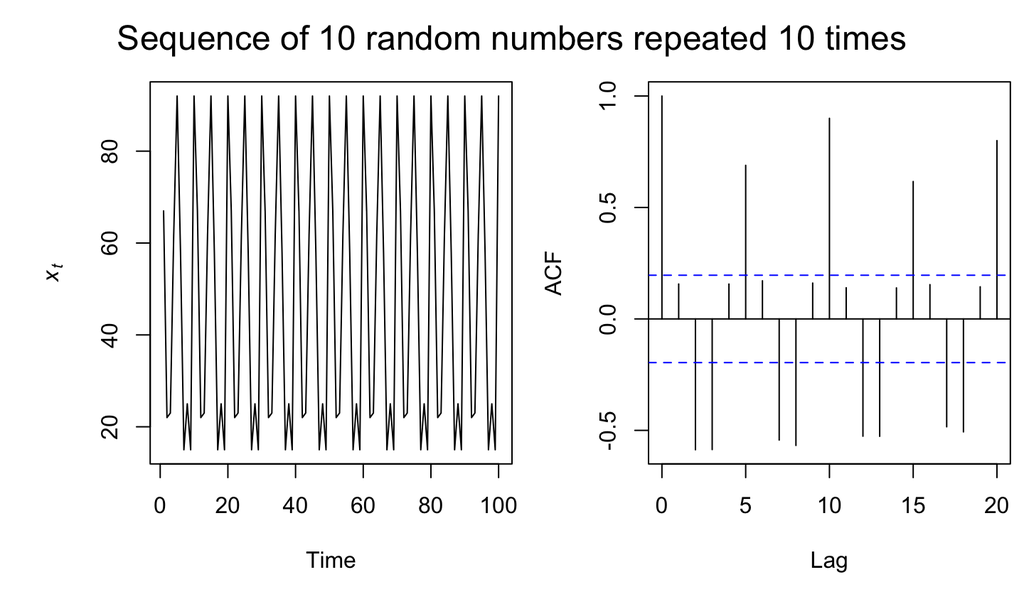

## Induced autocorrelation

Recall the transitive property, whereby

If \(A = B\) and \(B = C\), then \(A = C\)

## Induced autocorrelation

Recall the transitive property, whereby

If \(A = B\) and \(B = C\), then \(A = C\)

which suggests that

If \(x \propto y\) and \(y \propto z\), then \(x \propto z\)

## Induced autocorrelation

Recall the transitive property, whereby

If \(A = B\) and \(B = C\), then \(A = C\)

which suggests that

If \(x \propto y\) and \(y \propto z\), then \(x \propto z\)

and thus

If \(x_t \propto x_{t+1}\) and \(x_{t+1} \propto x_{t+2}\), then \(x_t \propto x_{t+2}\)

## Partial autocorrelation funcion (PACF)

The *partial autocorrelation function* (\(\phi_k\)) measures the correlation between a series \(x_t\) and \(x_{t+k}\) with the linear dependence of \(\{x_{t-1},x_{t-2},\dots,x_{t-k-1}\}\) removed

## Partial autocorrelation funcion (PACF)

The *partial autocorrelation function* (\(\phi_k\)) measures the correlation between a series \(x_t\) and \(x_{t+k}\) with the linear dependence of \(\{x_{t-1},x_{t-2},\dots,x_{t-k-1}\}\) removed

We can estimate \(\phi_k\) from a sample as

\[ \phi_k = \begin{cases} \text{Cor}(x_1,x_0) = \rho_1 & \text{if } k = 1 \\ \text{Cor}(x_k-x_k^{k-1}, x_0-x_0^{k-1}) & \text{if } k \geq 2 \end{cases} \]

\[ x_k^{k-1} = \beta_1 x_{k-1} + \beta_2 x_{k-2} + \dots + \beta_{k-1} x_1 \]

\[ x_0^{k-1} = \beta_1 x_1 + \beta_2 x_2 + \dots + \beta_{k-1} x_{k-1} \]

## Lake Washington phytoplankton

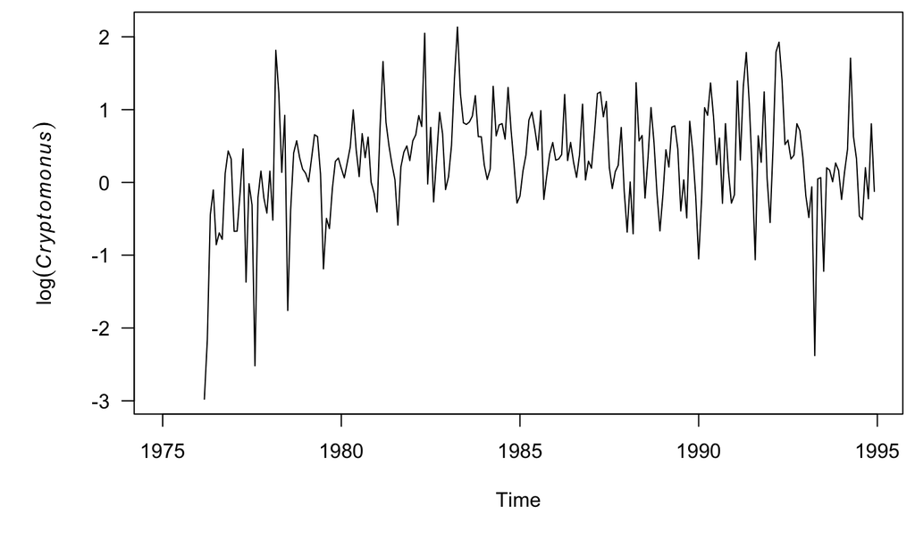

## Lake Washington phytoplankton

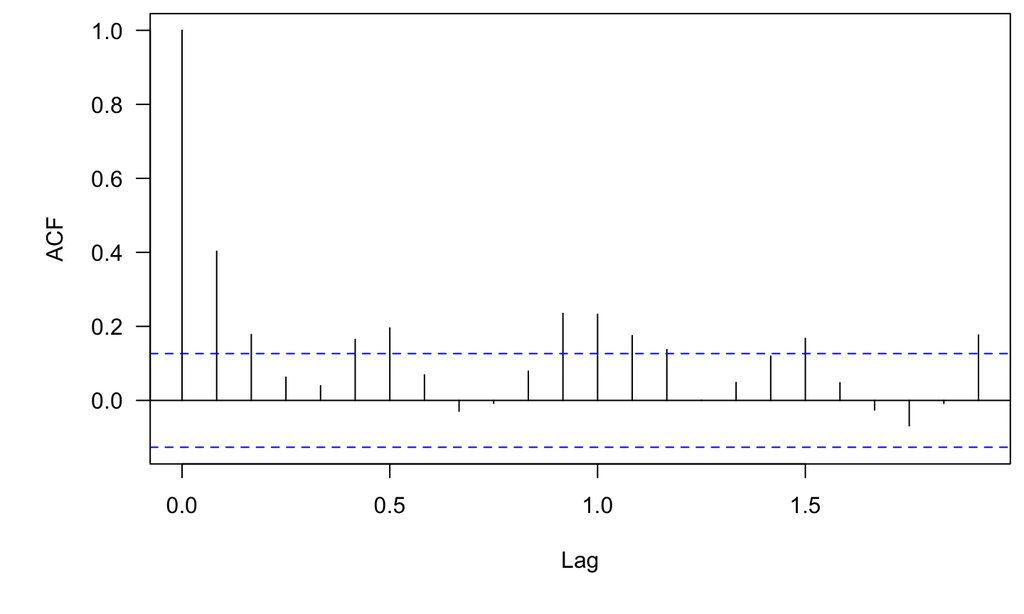

Autocorrelation

## Lake Washington phytoplankton

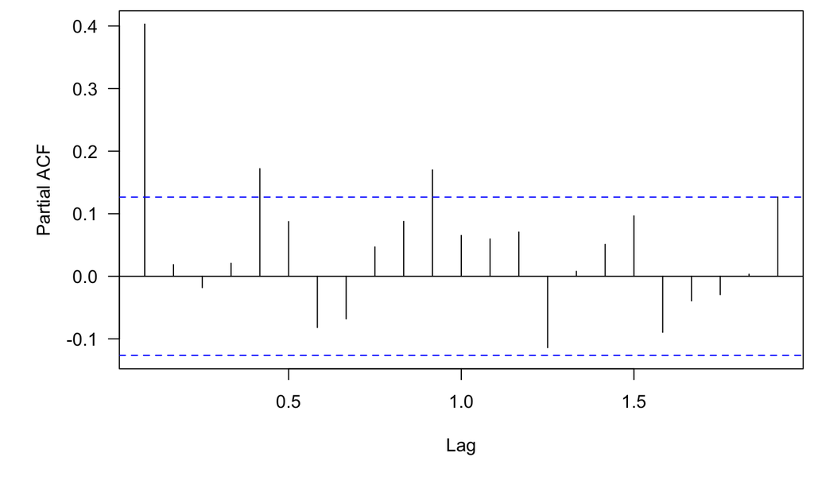

Partial autocorrelation

## ACF & PACF in model selection

We will see that the ACF & PACF are *very* useful for identifying the orders of ARMA models

## Cross-covariance function (CCVF)

Often we want to look for relationships between 2 different time series

We can extend the notion of covariance to *cross-covariance*

## Cross-covariance function (CCVF)

Often we want to look for relationships between 2 different time series

We can extend the notion of covariance to *cross-covariance*

We can estimate the CCVF \((g^{x,y}_k)\) from a sample as

\[ g^{x,y}_k = \frac{1}{N}\sum_{t=1}^{N-k}{(x_t - m_x)(y_{t+k} - m_y)} \]

## Cross-correlation function (CCF)

The cross-correlation function is the CCVF normalized by the standard deviations of x & y

\[ r^{x,y}_k = \frac{g^{x,y}_k}{s_x s_y} \]

Just as with other measures of correlation

\[ -1 \leq r^{x,y}_k \leq 1 \]

## Estimating the CCF in R

```r
ccf(x, y)
```

**Note**: the lag `k` value returned by `ccf(x, y)` is the correlation between `x[t+k]` and `y[t]`

In an explanatory context, we often think of \(y = f(x)\), so it’s helpful to use `ccf(y, x)` and only consider positive lags

## Example of cross-correlation

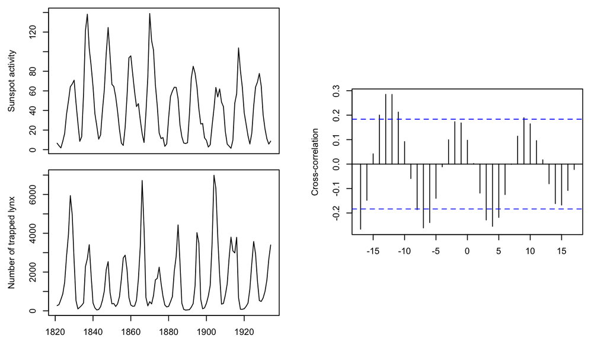

SOME SIMPLE MODELS

## White noise (WN)

A time series \(\{w_t\}\) is discrete white noise if its values are

1. independent
2. identically distributed with a mean of zero

## White noise (WN)

A time series \(\{w_t\}\) is discrete white noise if its values are

1. independent
2. identically distributed with a mean of zero

Note that distributional form for \(\{w_t\}\) is flexible

## White noise (WN)

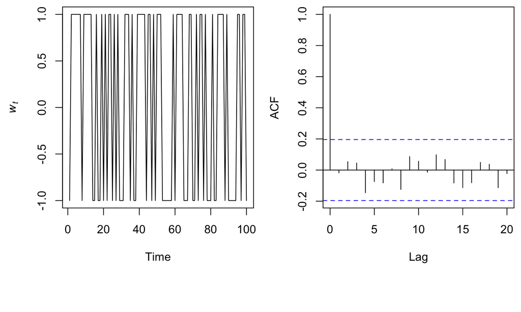

\(w_t = 2e_t - 1; e_t \sim \text{Bernoulli}(0.5)\)

## Gaussian white noise

We often assume so-called *Gaussian white noise*, whereby

\[ w_t \sim \text{N}(0,\sigma^2) \]

## Gaussian white noise

We often assume so-called *Gaussian white noise*, whereby

\[ w_t \sim \text{N}(0,\sigma^2) \]

and the following apply as well

autocovariance: \(\gamma_k = \begin{cases} \sigma^2 & \text{if } k = 0 \\ 0 & \text{if } k \geq 1 \end{cases}\)

autocorrelation: \(\rho_k = \begin{cases} 1 & \text{if } k = 0 \\ 0 & \text{if } k \geq 1 \end{cases}\)

## Gaussian white noise

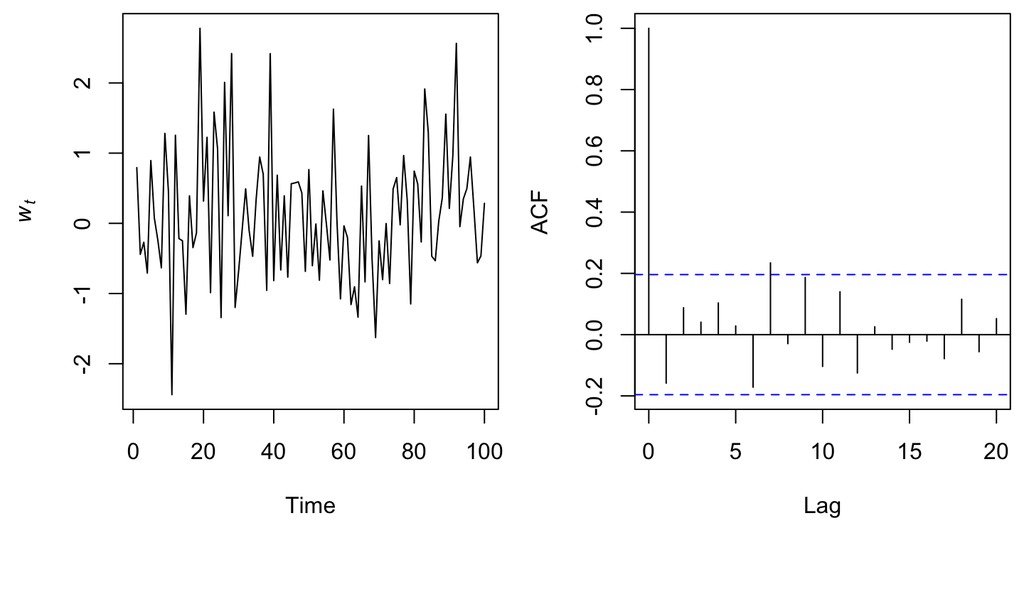

\(w_t \sim \text{N}(0,1)\)

## Random walk (RW)

A time series \(\{x_t\}\) is a random walk if

1. \(x_t = x_{t-1} + w_t\)
2. \(w_t\) is white noise

## Random walk (RW)

The following apply to random walks

mean: \(\mu_x = 0\)

autocovariance: \(\gamma_k(t) = t \sigma^2\)

autocorrelation: \(\rho_k(t) = \frac{t \sigma^2}{\sqrt{t \sigma^2(t + k) \sigma^2}}\)

## Random walk (RW)

The following apply to random walks

mean: \(\mu_x = 0\)

autocovariance: \(\gamma_k(t) = t \sigma^2\)

autocorrelation: \(\rho_k(t) = \frac{t \sigma^2}{\sqrt{t \sigma^2(t + k) \sigma^2}}\)

*Note*: Random walks are not stationary

## Random walk (RW)

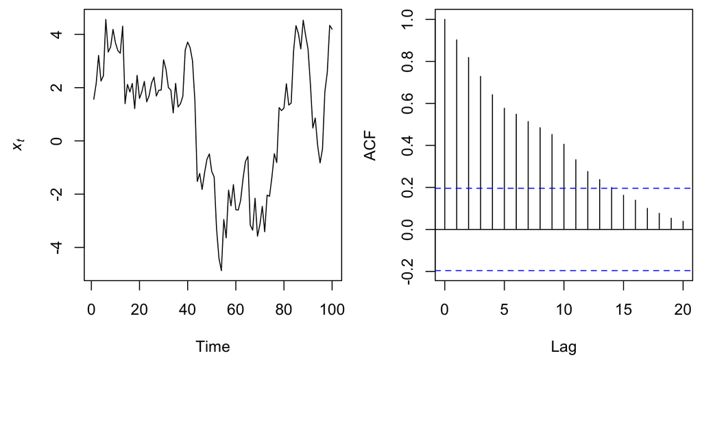

\(x_t = x_{t-1} + w_t; w_t \sim \text{N}(0,1)\)

SOME IMPORTANT OPERATORS

## The backshift shift operator

The *backshift shift operator* (\(\mathbf{B}\)) is an important function in time series analysis, which we define as

\[ \mathbf{B} x_t = x_{t-1} \]

or more generally as

\[ \mathbf{B}^k x_t = x_{t-k} \]

## The backshift shift operator

For example, a random walk with

\[ x_t = x_{t-1} + w_t \]

can be written as

\[ \begin{align} x_t &= \mathbf{B} x_t + w_t \\ x_t - \mathbf{B} x_t &= w_t \\ (1 - \mathbf{B}) x_t &= w_t \\ x_t &= (1 - \mathbf{B})^{-1} w_t \end{align} \]

## The difference operator

The *difference operator* (\(\nabla\)) is another important function in time series analysis, which we define as

\[ \nabla x_t = x_t - x_{t-1} \]

## The difference operator

The *difference operator* (\(\nabla\)) is another important function in time series analysis, which we define as

\[ \nabla x_t = x_t - x_{t-1} \]

For example, first-differencing a random walk yields white noise

\[ \begin{align} \nabla x_t &= x_{t-1} + w_t \\ x_t - x_{t-1} &= x_{t-1} + w_t - x_{t-1}\\ x_t - x_{t-1} &= w_t\\ \end{align} \]

## The difference operator

The difference operator and the backshift operator are related

\[ \nabla^k = (1 - \mathbf{B})^k \]

## The difference operator

The difference operator and the backshift operator are related

\[ \nabla^k = (1 - \mathbf{B})^k \]

For example

\[ \begin{align} \nabla x_t &= (1 - \mathbf{B})x_t \\ x_t - x_{t-1} &= x_t - \mathbf{B} x_t \\ x_t - x_{t-1} &= x_t - x_{t-1} \end{align} \]

## Differencing to remove a trend

Differencing is a simple means for removing a trend

The 1st-difference removes a linear trend

A 2nd-difference will remove a quadratic trend

## Differencing to remove a trend

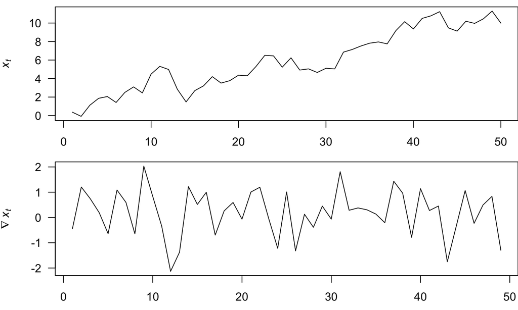

## Differencing to remove seasonality

Differencing is a simple means for removing a seasonal effect

Using a 1st-difference with \(k = period\) removes both trend & seasonal effects

## Differencing to remove seasonality

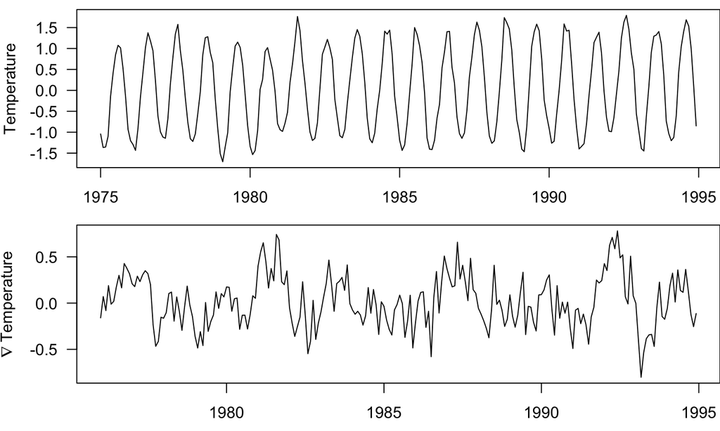

## Differencing to remove a trend in R

We can use `diff()` to easily compute differences

```r
diff(x,
     lag,
     differences
     )
```

## Differencing to remove a trend in R

```r
diff(x,
     lag,
     differences
     )
```

`lag` \((h)\) specifies \(t - h\)

`lag = 1` (default) is for non-seasonal data

`lag = 4` would work for quarterly data or

`lag = 12` for monthly data

## Differencing to remove a trend in R

```r
diff(x,
     lag,
     differences
     )
```

`differences` is the number of differencing operations

`differences = 1` (default) is for a linear trend

`differences = 2` is for a quadratic trend

## Topics for today

Characteristics of time series

- Expectation, mean & variance
- Covariance & correlation
- Stationarity
- Autocovariance & autocorrelation
- Correlograms

White noise

Random walks

Backshift & difference operators